# Simulated data

In this Notebook we create a simulated dataset and we carry out a complete calibration procedure, also with the representation of the estimated coefficients. The required libraries are loaded

```r
library(plot3D)
library(GWmodel)
library(psych)
library(ggplot2)
library(reshape2)
```

The required functions are loaded

```r
source("functions.R")
```

We build two grids in a range from -5 to 5 with step equal to 0.5, in order to have station- and event-coordinates

```r
inf = -5
sup = 5
step = 0.5
x = s1 = s2 = e1 = e2 = seq(inf, sup, by = step)
adj = (length(x)+1)/2

grid_e_sim = matrix(0,(length(e1)*length(e2)),2)
for (i in 1:length(e1)){
  for (j in 1:length(e2)){
    grid_e_sim[j+(i-1)*length(s2),] = c(e1[i],e2[j])
  }
}

grid_s_sim = matrix(0,(length(s1)*length(s2)),2)
for (i in 1:length(s1)){
  for (j in 1:length(s2)){
    grid_s_sim[j+(i-1)*length(s2),] = c(s1[i],s2[j])
  }
}
```

The regression coefficients are set and, in the case of spatial non-stationarity, they are also plotted

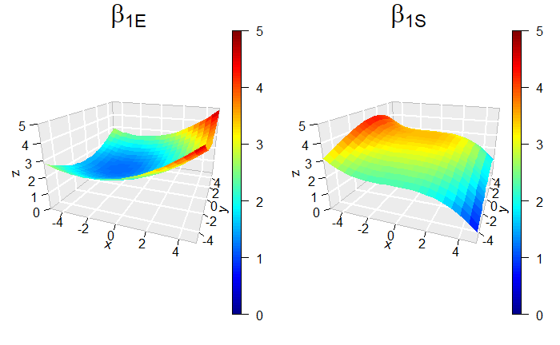

```r
#beta_c intercept
beta_c_intercept_true = 8

#beta_c variable
beta_c_variable_true = 4

par(mfrow=c(1,2), mai = c(0.4, 0.4, 0.4, 0.4))

#beta_e variable
beta_e_variable_true = matrix(0,length(e1), length(e2))
beta_e_variable_true_col = matrix(0,length(e1)*length(e2),3)
for (i in 1:length(e1)){
  for (j in 1:length(e2)){
    beta_e_variable_true[i,j] = +0.05*(e1[i]+1)^2 + 0.05*(e2[j])^2 + 1.5 + 0.1*(e1[i]-2)
    beta_e_variable_true_col[j+(i-1)*length(e2),] = c(beta_e_variable_true[i,j],e1[i],e2[j])
  }
}

persp3D(e1,e2,beta_e_variable_true, colvar = beta_e_variable_true,theta=20,
        phi=20,axes= TRUE,scale=2, box=TRUE, nticks=5,
        ticktype="detailed",
        xlab="x",
        ylab="y",
        zlab="z",
        zlim = c(0,5),
        clim = c(0,5),
        cex.main = 2,
        expand = 0.6,
        bty = "g",
        main=expression(paste(beta["1E"]))
)

#beta_s variable
beta_s_variable_true = matrix(0,length(s1), length(s2))
beta_s_variable_true_col = matrix(0,length(s1)*length(s2),3)
for (i in 1:length(s1)){
  for (j in 1:length(s2)){
    beta_s_variable_true[i,j] = -0.01*(s1[i]+0.5)^3 - 0.01*(s2[j]-0.5)^3 + 0.007*(s2[j]-2.5)^3+3.5
    beta_s_variable_true_col[j+(i-1)*length(s2),] = c(beta_s_variable_true[i,j],s1[i],s2[j])
  }
}

persp3D(s1,s2,beta_s_variable_true, colvar = beta_s_variable_true,theta=20,
        phi=20,axes= TRUE,scale=2, box=TRUE, nticks=5,
        ticktype="detailed",
        xlab="x",
        ylab="y",
        zlab="z",
        zlim = c(0,5),
        clim = c(0,5),
        cex.main = 2,
        expand = 0.6,
        bty = "g",
        main=expression(paste(beta["1S"]))
)
```

Now we have to create the dataset, along some normal distributions, considering a stationary intercept and three covariates, a stationary one, a site-dependent one and an event-dependent one. The response variables are also computed, after introducing the error term.

```r
#create X
set.seed(6494)
n = length(s1)^4
Xc_var = rnorm(n, 3, 5)
Xe_var = rnorm(n, -4, 5)
Xs_var = rnorm(n, 4, 5)
Xc = cbind(rep(1,n), Xc_var)
Xe = Xe_var
Xs = Xs_var

#create variance on four dimensional grid
epsilon = rnorm(n,0,2)

n = length(s1)^4 #create "four-dimensional grid"
f = 4
l = rep(list(x), f)
coords = expand.grid(l)
X_coords = cbind(Xc_var, Xe_var, Xs_var, coords, epsilon)
names(X_coords)[4:7]=c("E1", "E2", "S1", "S2")

#compute response y
beta_c_true = cbind(beta_c_intercept_true, beta_c_variable_true)
beta_s_true = beta_s_variable_true_col
beta_e_true = beta_e_variable_true_col
yc = rep(0,n)
for (i in 1:n){
   coords_e = X_coords[i,4:5]
   coords_s = X_coords[i,6:7]
   yc[i] = Xc[i,]%*%t(beta_c_true) +
     Xe_var[i]*beta_e_variable_true[coords_e[[1]]/step+adj,coords_e[[2]]/step+adj] +
     Xs_var[i]*beta_s_variable_true[coords_s[[1]]/step+adj,coords_s[[2]]/step+adj] +
     epsilon[i]
}
```

The next step is to create our simulation subset, made of 80 elements picked casually from our generated dataset

```r
set.seed(2803)
n_sample = 80
lines = sample(1:n, n_sample)
ordered_lines = sort(lines)
X_sim = X_coords[ordered_lines,]
y_sim_c = yc[ordered_lines]

grid_sim = matrix(0,(length(s1)*length(s2)),2)
for (i in 1:length(s1)){
  for (j in 1:length(s2)){
    grid_sim[j+(i-1)*length(s2),] = c(s1[i],s2[j])
  }
}

coords_e_sim = cbind(X_sim$E1, X_sim$E2)
coords_s_sim = cbind(X_sim$S1, X_sim$S2)
```

We compute the best bandwidth for the complete model, since we assume it to be the correct one; morover we see if it is better to use ESC or SEC. Notice that in this example we force $bw_e = bw_s$

```r
bw_sec = bw_cv(0.5,3.2,0.15,80,SEC_only_calibration, "sec", X_sim$Xc_var, X_sim$Xe_var, X_sim$Xs_var, y_sim_c,
         "c", coords_e_sim, coords_s_sim)
bw_esc = bw_cv(0.5,3.2,0.15,80,ESC_only_calibration, "esc", X_sim$Xc_var, X_sim$Xe_var, X_sim$Xs_var, y_sim_c,
         "c", coords_e_sim, coords_s_sim)
```

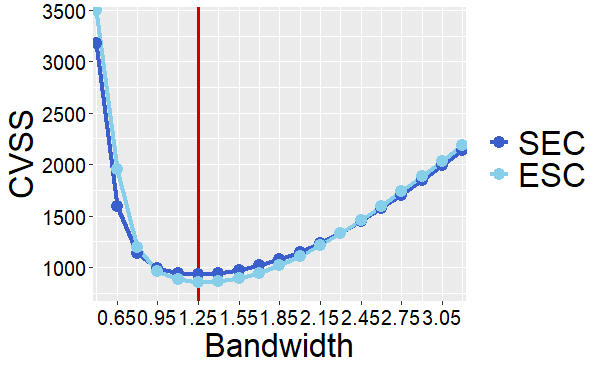

```r
cvsum_sec = bw_sec[[2]][,2]
cvsum_esc = bw_esc[[2]][,2]
bws = bw_esc[[2]][,1]
dataset = as.data.frame(cbind(bws, cvsum_sec, cvsum_esc))
melted = melt(dataset, id.vars = "bws")

ggplot(melted, aes(x=bws, y=value, col=variable)) +
  geom_line(size = 1.7)+
  labs(y = "CVSS", x = "Bandwidth")+
  scale_color_manual(values=c("royalblue3","skyblue"),labels = c("SEC", "ESC"))+
  theme(axis.text=element_text(size=15, colour = "black"),
        axis.title=element_text(size=25),
        legend.text=element_text(size=25, colour = "black"),
        legend.title = element_blank(),
        legend.key = element_rect(fill = NA)
  )+
  scale_x_continuous(breaks = seq(from = 0.65, to = 3.05, by = 0.3)) +
  geom_vline(xintercept = 1.25, size = 1.2, colour="red3")+
  coord_cartesian(xlim = c(0.6, 3.1),ylim = c(800, 3400))+
  geom_point(size = 4)
```

Both ESC and SEC lead to $bw_e = bw_s = 1.25$, but ESC performs better as far as CVSS is concerned. Now we proceed by carrying out the permutation test, to verify if we are considering the right model. To carry out all these tests, we use the bandwidth which are found for the complete model in the previous point. At first we verify if it is reasonable to introduce spatial non-stationarity

```r
#OLS vs completely varying
ols = lm(y_sim_c ~ X_sim$Xc_var + X_sim$Xe_var + X_sim$Xs_var)
bwe = bws = 1.25
esc_only_intercept = ESC_only_constant_intercept_calibration(cbind(X_sim$Xc_var, X_sim$Xe_var), X_sim$Xs_var, y_sim_c, bwe, bws, coords_e_sim, coords_s_sim)
#compute R(H0)
X = cbind(rep(1,n_sample), X_sim$Xc_var, X_sim$Xe_var, X_sim$Xs_var)
I = diag(1,n_sample)
Hols = X%*%(solve(t(X)%*%X))%*%t(X)
RH0 = t(I-Hols)%*%(I-Hols)
eps = (I-Hols)%*%y_sim_c
#compute R(H1)
B = esc_only_intercept$B
Xcc = rep(1,dim(X_sim)[1])
H1 = I - B + B %*% Xcc %*% solve(t(Xcc)%*%t(B)%*%B%*%Xcc) %*% t(Xcc) %*% t(B)%*% B
RH1 = t(I-H1)%*%(I-H1)
#compute T
T0 = (t(y_sim_c) %*% (RH0-RH1) %*% y_sim_c) / (t(y_sim_c) %*% RH1 %*% y_sim_c)
#permutations
n_perm = 1000
t_stat = rep(0,n_perm)
set.seed(6494)
for (i in 1:n_perm){
  eps_star = sample(eps)
  y_star = Hols %*% y_sim_c + eps_star
  t_stat[i] = (t(y_star) %*% (RH0-RH1) %*% y_star) / (t(y_star) %*% RH1 %*% y_star)
}
```

```r
p = sum(t_stat>as.numeric(T0))/n_perm
p
```

```
[1] 0
```

Then we check if it is correct to consider Xc as constant and Xe and Xs as spatially varying

```r
#check if Xc is constant
#calibrate models under H0 and H1
esc = ESC_only_calibration(X_sim$Xc_var, X_sim$Xe_var, X_sim$Xs_var, y_sim_c, "c", bwe, bws, coords_e_sim, coords_s_sim)
esc_only_intercept = ESC_only_constant_intercept_calibration(cbind(X_sim$Xc_var, X_sim$Xe_var), X_sim$Xs_var, y_sim_c, bwe, bws, coords_e_sim, coords_s_sim)
#compute R(H0)
I= diag(1,n_sample)
B = esc$B
Xcc = cbind(rep(1,dim(X_sim)[1]), X_sim$Xc_var)
H0 = I - B + B %*% Xcc %*% solve(t(Xcc)%*%t(B)%*%B%*%Xcc) %*% t(Xcc) %*% t(B)%*% B
RH0 = t(I-H0)%*%(I-H0)
eps = (I-H0)%*%y_sim_c
#compute R(H1)
B = esc_only_intercept$B
Xcc = rep(1,dim(X_sim)[1])
H1 = I - B + B %*% Xcc %*% solve(t(Xcc)%*%t(B)%*%B%*%Xcc) %*% t(Xcc) %*% t(B)%*% B
RH1 = t(I-H1)%*%(I-H1)
#compute T
T0 = (t(y_sim_c) %*% (RH0-RH1) %*% y_sim_c) / (t(y_sim_c) %*% RH1 %*% y_sim_c)
#permutations
n_perm = 1000
t_stat = rep(0,n_perm)
set.seed(6494)
for (i in 1:n_perm){
  eps_star = sample(eps)
  y_star = H0 %*% y_sim_c + eps_star
  t_stat[i] = (t(y_star) %*% (RH0-RH1) %*% y_star) / (t(y_star) %*% RH1 %*% y_star)
}
```

```r
p_xc = sum(t_stat>as.numeric(T0))/n_perm
p_xc
```

```
[1] 0.598
```

```r
#check if Xe is constant
#calibrate models under H0 and H1
esc = ESC_only_calibration(X_sim$Xe_var, X_sim$Xc_var, X_sim$Xs_var, y_sim_c, "c", bwe, bws, coords_e_sim, coords_s_sim)
esc_only_intercept = ESC_only_constant_intercept_calibration(cbind(X_sim$Xe_var, X_sim$Xc_var), X_sim$Xs_var, y_sim_c, bwe, bws, coords_e_sim, coords_s_sim)
#compute R(H0)
I= diag(1,n_sample)
B = esc$B
Xcc = cbind(rep(1,dim(X_sim)[1]), X_sim$Xe_var)
H0 = I - B + B %*% Xcc %*% solve(t(Xcc)%*%t(B)%*%B%*%Xcc) %*% t(Xcc) %*% t(B)%*% B
RH0 = t(I-H0)%*%(I-H0)
eps = (I-H0)%*%y_sim_c
#compute R(H1)
B = esc_only_intercept$B
Xcc = rep(1,dim(X_sim)[1])
H1 = I - B + B %*% Xcc %*% solve(t(Xcc)%*%t(B)%*%B%*%Xcc) %*% t(Xcc) %*% t(B)%*% B
RH1 = t(I-H1)%*%(I-H1)
#compute T
T0 = (t(y_sim_c) %*% (RH0-RH1) %*% y_sim_c) / (t(y_sim_c) %*% RH1 %*% y_sim_c)
#permutations
n_perm = 1000
t_stat = rep(0,n_perm)
for (i in 1:n_perm){
  eps_star = sample(eps)
  y_star = H0 %*% y_sim_c + eps_star
  t_stat[i] = (t(y_star) %*% (RH0-RH1) %*% y_star) / (t(y_star) %*% RH1 %*% y_star)
}
```

```r
p_xe = sum(t_stat>as.numeric(T0))/n_perm
p_xe
```

```
[1] 0
```

```r
#check if Xs is constant
#calibrate models under H0 and H1
esc = mixed_SC_calibration(X_sim$Xs_var, cbind(X_sim$Xe_var, X_sim$Xc_var), y_sim_c, 1.25, "c", coords_e_sim)
esc_only_intercept = ESC_only_constant_intercept_calibration(cbind(X_sim$Xe_var, X_sim$Xc_var), X_sim$Xs_var, y_sim_c, bwe, bws, coords_e_sim, coords_s_sim)
#compute R(H0)
I= diag(1,n_sample)
Hs = esc$Hs
Xcc = cbind(rep(1,dim(X_sim)[1]), X_sim$Xs_var)
# H0 = I - B + B %*% Xcc %*% solve(t(Xcc)%*%t(B)%*%B%*%Xcc) %*% t(Xcc) %*% t(B)%*% B
H0 = Hs + (I-Hs)%*%Xcc%*%solve(t(Xcc)%*%t(I-Hs)%*%(I-Hs)%*%Xcc)%*%t(Xcc)%*%t(I-Hs)%*%(I-Hs)
RH0 = t(I-H0)%*%(I-H0)
eps = (I-H0)%*%y_sim_c
#compute R(H1)
B = esc_only_intercept$B
Xcc = rep(1,dim(X_sim)[1])
H1 = I - B + B %*% Xcc %*% solve(t(Xcc)%*%t(B)%*%B%*%Xcc) %*% t(Xcc) %*% t(B)%*% B
RH1 = t(I-H1)%*%(I-H1)
#compute T
T0 = (t(y_sim_c) %*% (RH0-RH1) %*% y_sim_c) / (t(y_sim_c) %*% RH1 %*% y_sim_c)
#permutations
n_perm = 1000
t_stat = rep(0,n_perm)
for (i in 1:n_perm){
  eps_star = sample(eps)
  y_star = H0 %*% y_sim_c + eps_star
  t_stat[i] = (t(y_star) %*% (RH0-RH1) %*% y_star) / (t(y_star) %*% RH1 %*% y_star)
}
```

```r
p_xs = sum(t_stat>as.numeric(T0))/n_perm
p_xs
```

```
[1] 0
```

The next step is to check if the constant terms can be considered as null

```r
#check if the intercept is null
#calibrate models under H0 and H1
esc_null = mixed_SC_no_intercept_calibration(X_sim$Xc_var, X_sim$Xs_var, y_sim_c, 1.25, coords_s_sim)
esc = ESC_only_calibration(X_sim$Xc_var, X_sim$Xe_var, X_sim$Xs_var, y_sim_c, "c", bwe, bws, coords_e_sim, coords_s_sim)
#compute R(H0)
I= diag(1,n_sample)
Hs = esc_null$Hs
Xcc = cbind(rep(1,dim(X_sim)[1]), X_sim$Xc_var)
H0 = Hs + (I-Hs)%*%Xcc%*%solve(t(Xcc)%*%t(I-Hs)%*%(I-Hs)%*%Xcc)%*%t(Xcc)%*%t(I-Hs)%*%(I-Hs)
RH0 = t(I-H0)%*%(I-H0)
eps = (I-H0)%*%y_sim_c
#compute R(H1)
I= diag(1,n_sample)
B = esc$B
Xcc = cbind(rep(1,dim(X_sim)[1]), X_sim$Xc_var)
H1 = I - B + B %*% Xcc %*% solve(t(Xcc)%*%t(B)%*%B%*%Xcc) %*% t(Xcc) %*% t(B)%*% B
RH1 = t(I-H1)%*%(I-H1)
#compute T
T0 = (t(y_sim_c) %*% (RH0-RH1) %*% y_sim_c) / (t(y_sim_c) %*% RH1 %*% y_sim_c)
#permutations
n_perm = 1000
t_stat = rep(0,n_perm)
for (i in 1:n_perm){
  eps_star = sample(eps)
  y_star = H0 %*% y_sim_c + eps_star
  t_stat[i] = (t(y_star) %*% (RH0-RH1) %*% y_star) / (t(y_star) %*% RH1 %*% y_star)
}
```

```r
p_intercept_null = sum(t_stat>as.numeric(T0))/n_perm
p_intercept_null
```

```
[1] 0
```

```r
#check if Xc is null
#calibrate models under H0 and H1
esc_null = mixed_SC_no_intercept_calibration(rep(1,length(X_sim$Xe_var)), X_sim$Xe_var, y_sim_c, 1.25, coords_e_sim)
esc = ESC_only_calibration(X_sim$Xc_var, X_sim$Xe_var, X_sim$Xs_var, y_sim_c, "c", bwe, bws, coords_e_sim, coords_s_sim)
#compute R(H0)
I= diag(1,n_sample)
Hs = esc_null$Hs
Xcc = cbind(rep(1,dim(X_sim)[1]), X_sim$Xc_var)
H0 = Hs + (I-Hs)%*%Xcc%*%solve(t(Xcc)%*%t(I-Hs)%*%(I-Hs)%*%Xcc)%*%t(Xcc)%*%t(I-Hs)%*%(I-Hs)
RH0 = t(I-H0)%*%(I-H0)
eps = (I-H0)%*%y_sim_c
#compute R(H1)
I= diag(1,n_sample)
B = esc$B
Xcc = cbind(rep(1,dim(X_sim)[1]), X_sim$Xc_var)
H1 = I - B + B %*% Xcc %*% solve(t(Xcc)%*%t(B)%*%B%*%Xcc) %*% t(Xcc) %*% t(B)%*% B
RH1 = t(I-H1)%*%(I-H1)
#compute T
T0 = (t(y_sim_c) %*% (RH0-RH1) %*% y_sim_c) / (t(y_sim_c) %*% RH1 %*% y_sim_c)
#permutations
n_perm = 1000
t_stat = rep(0,n_perm)
for (i in 1:n_perm){
  eps_star = sample(eps)
  y_star = H0 %*% y_sim_c + eps_star
  t_stat[i] = (t(y_star) %*% (RH0-RH1) %*% y_star) / (t(y_star) %*% RH1 %*% y_star)
}
```

```r
p_xc_null = sum(t_stat>as.numeric(T0))/n_perm
p_xc_null
```

```
[1] 0
```

We can now execute the whole calibration, using the previously obtained results to set parameters and methods

```r
bwe = bws = 1.25
esc = ESC_general(X_sim$Xc_var, X_sim$Xe_var, X_sim$Xs_var, y_sim_c, "c", bwe, bws, coords_e_sim, coords_s_sim, as.matrix(grid_sim))

betas_c = esc$beta_c
betas_c
```

```
       [,1]
   8.192266
Xc 4.007947
```

The spatially varying coefficients can be graphically compared with the true ones

```r
beta_s = esc$beta_s
beta_e = esc$beta_e

beta_s_grid = matrix(0, length(s1),length(s2))
k=1
for (i in 1:length(s1)){
  for (j in 1:length(s2)){
    beta_s_grid[i,j] = beta_s[1,k]
    k = k+1
  }
}

beta_e_grid = matrix(0, length(e1),length(e2))
k=1
for (i in 1:length(e1)){
  for (j in 1:length(e2)){
    beta_e_grid[i,j] = beta_e[1,k]
    k = k+1
  }
}

par(mfrow=c(2,2),  mai = c(0.4, 0.4, 0.4, 0.4))
persp3D(e1,e2,beta_e_variable_true, colvar = beta_e_variable_true,theta=30,
        phi=40,axes= TRUE,scale=2, box=TRUE, nticks=5,
        ticktype="detailed",
        xlab="x",
        ylab="y",
        zlab="z",
        zlim = c(0,5),
        clim = c(0,5),
        cex.main = 2,
        expand = 0.6,
        bty = "g",
        main=expression(paste(beta["1E"]))
)

persp3D(s1,s2,beta_s_variable_true, colvar = beta_s_variable_true,theta=30,
        phi=40,axes= TRUE,scale=2, box=TRUE, nticks=5,
        ticktype="detailed",
        xlab="x",
        ylab="y",
        zlab="z",
        zlim = c(0,5),
        clim = c(0,5),
        cex.main = 2,
        expand = 0.6,
        bty = "g",
        main=expression(paste(beta["1S"]))
)
```

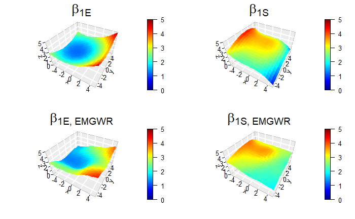

```r
persp3D(e1,e2,beta_e_grid, colvar = beta_e_grid,theta=30,
        phi=40,axes= TRUE,scale=2, box=TRUE, nticks=5,
        ticktype="detailed",
        xlab="x",
        ylab="y",
        zlab="z",
        zlim = c(0,5),
        clim = c(0,5),
        cex.main = 2,
        expand = 0.6,
        bty = "g",
        main=expression(paste(beta["1E, EMGWR"]))
)

persp3D(s1,s2,beta_s_grid, colvar = beta_s_grid,theta=30,
        phi=40,axes= TRUE,scale=2, box=TRUE, nticks=5,
        ticktype="detailed",
        xlab="x",
        ylab="y",
        zlab="z",
        zlim = c(0,5),
        clim = c(0,5),
        cex.main = 2,
        expand = 0.6,
        bty = "g",
        main=expression(paste(beta["1S, EMGWR"]))
)
```

Finally we can compute $R^2_{adj}$

```r
I= diag(1,n_sample)
B = esc$B
Xcc = cbind(rep(1,dim(X_sim)[1]), X_sim$Xc_var)
H_esc = I - B + B %*% Xcc %*% solve(t(Xcc)%*%t(B)%*%B%*%Xcc) %*% t(Xcc) %*% t(B)%*% B
res = (I-H_esc)%*%y_sim_c
delta1 = n_sample-2*tr(H_esc)+tr(t(H_esc)%*%H_esc)
rss = sum(res^2)
sigma2hat = rss/delta1
tss = sum((H_esc%*%y_sim_c-mean(y_sim_c))^2)
R2 = 1-rss/tss
R2adj = 1-(1-R2)*(n_sample-1)/delta1
R2adj
```

```
[1] 0.9927192
```